# NFL exercise - SOLUTION

Mirko Mälicke

# 1 Solution

This is the solution.

**This is not a mandatory exercise. You can do this exercise in case you have still trouble with basic SQL query syntax and logic.**

In case you need more practice with basic SQL query structure and the logic behind a data manipulation using SQL, this exercise is perfect. It does not include any environmental data, thus you will be forced to think outside your comfort zone of time-series data. You will only need the `nfl` table in the database. This collects all NFL (National Football League) games of the 2016 / 2017 regular season (no Playoffs included). Each entry gives the data, home team, vistor team and the score of both teams. Try to solve all given tasks.

# 2 Get to know the data

How many games does a regualar season in the NFL include?

```sql
SELECT count(*) AS "amount of games" FROM nfl
```

| amount of games |
| --- |
| 256 |

How many teams are organized in the NFL?

```sql
SELECT count(DISTINCT home_team) AS "amount of teams" FROM nfl
```

| amount of teams |
| --- |
| 32 |

How many games does a NFL team complete? Will all teams play against each other (just like in the Bundesliga)?

```sql
SELECT 256 / 32 AS "games per team"
```

| games per team |
| --- |
| 8 |

Which are the NFL teams of 2016?

```sql
SELECT DISTINCT home_team from nfl
```

| home_team |
| --- |
| Carolina Panthers |
| Green Bay Packers |
| Chicago Bears |
| Buffalo Bills |
| San Diego Chargers |
| Oakland Raiders |
| Cincinnati Bengals |
| Cleveland Browns |
| Minnesota Vikings |
| Tampa Bay Buccaneers |

[output cut: 22 more lines]

One of my favorite Quarterbacks, Cam Newton, played 2016 on my birthday, which is Sep. 8th. Did Cam win his game?

```sql
SELECT  visitor_team || ' @ ' || home_team || ': ' || visitor_score || '-' || home_score AS "my birthday game" FROM nfl
WHERE date = '2016-09-08 00:00:00'
```

| my birthday game |
| --- |
| Denver Broncos @ Carolina Panthers: 21-20 |

How many teams from New York play in the NFL?

```sql
SELECT DISTINCT home_team FROM nfl WHERE home_team LIKE '%NEW YORK%'
```

| home_team |
| --- |
| New York Giants |
| New York Jets |

How many Los Angeles teams played in the NFL in 2016?

```sql
SELECT DISTINCT home_team FROM nfl WHERE home_team LIKE '%Los Angeles%'
```

| home_team |
| --- |
| Los Angeles Rams |

In 2017 preseason the Los Angeles Chargers celebrated a close victory over the Los Angeles Rams of 21:19. As you learned from the previos chunk, there was no Los Angeles Chargers team in 2016. Where were the Chargers located until 2016?

```sql
SELECT DISTINCT home_team FROM nfl WHERE home_team LIKE '%Chargers%'
```

| home_team |
| --- |
| San Diego Chargers |

# 3 Working with the data

Enough preliminary data exploration. Now, let’s work with the data.  
Create a view on the nfl table which adds a boolean information on whether the home team won the game or not.

```sql
CREATE TEMPORARY VIEW  home_win AS
  SELECT *, home_score > visitor_score as home_win FROM nfl;
```

```sql
SELECT * FROM home_win
```

| game_id | date | home_team | home_score | visitor_team | visitor_score | home_win |
| --- | --- | --- | --- | --- | --- | --- |
| 1 | 2016-09-08 00:00:00 | Carolina Panthers | 20 | Denver Broncos | 21 | 0 |
| 2 | 2016-09-11 00:00:00 | Green Bay Packers | 27 | Jacksonville Jaguars | 23 | 1 |
| 3 | 2016-09-11 00:00:00 | Chicago Bears | 14 | Houston Texans | 23 | 0 |
| 4 | 2016-09-11 00:00:00 | Buffalo Bills | 7 | Baltimore Ravens | 13 | 0 |
| 5 | 2016-09-11 00:00:00 | San Diego Chargers | 27 | Kansas City Chiefs | 33 | 0 |
| 6 | 2016-09-11 00:00:00 | Oakland Raiders | 35 | New Orleans Saints | 34 | 1 |
| 7 | 2016-09-11 00:00:00 | Cincinnati Bengals | 23 | New York Jets | 22 | 1 |
| 8 | 2016-09-11 00:00:00 | Cleveland Browns | 10 | Philadelphia Eagles | 29 | 0 |
| 9 | 2016-09-11 00:00:00 | Minnesota Vikings | 25 | Tennessee Titans | 16 | 1 |
| 10 | 2016-09-11 00:00:00 | Tampa Bay Buccaneers | 31 | Atlanta Falcons | 24 | 1 |

[output cut: 246 more lines]

Is there a home game advantage?

```sql
SELECT 'home wins' as description, count(game_id) as amount from home_win where home_win=1
UNION
SELECT 'visitor wins' as description, count(game_id) as amount from home_win where home_win=0
```

| description | amount |
| --- | --- |
| home wins | 107 |
| visitor wins | 149 |

Which team had the most home victories, which won the fewest? Select both teams in a union statement.

```sql
Select home_team, "won home games" FROM (Select home_team, count(home_win) "won home games" from home_win where home_win=1
  group by home_team order by "won home games" DESC LIMIT 1) as most
UNION
Select home_team, "won home games" FROM (Select home_team, count(home_win) "won home games" from home_win where home_win=1
  group by home_team order by "won home games" ASC LIMIT 1) as fewest
ORDER BY "won home games" DESC
```

| home_team | won home games |
| --- | --- |
| New England Patriots | 8 |
| Jacksonville Jaguars | 1 |

Because of the American Football rules ties are very sparse in the NFL. From 1997 to 2015 there were overall only three ties. How many ties happened 2016?

```sql
SELECT * from nfl where home_score=visitor_score
```

| game_id | date | home_team | home_score | visitor_team | visitor_score |
| --- | --- | --- | --- | --- | --- |
| 106 | 2016-10-23 00:00:00 | Seattle Seahawks | 6 | Arizona Cardinals | 6 |
| 109 | 2016-10-30 00:00:00 | Washington Redskins | 27 | Cincinnati Bengals | 27 |

# 4 Aggregation

Other than in the Bundesliga, a NFL team won’t earn points for a victory. The teams are split up into *divisions* of four teams. The team with most victories will win the division and go to the playoffs. Therefore the record is the most important statistic for the teams. Before the 11th game day, the Green Bay Packers had a `Green Bay Packers 4-6` record, meaning they lost 6 out of 10 games.  
How did the Green Bay Packer do? What was their record at the end of the regular season?

```sql
create temporary view team_record as
select team_name, sum(won_home) as won, 16 - sum(won_home) as lost From (
    SELECT home_team as team_name, count(home_win) as won_home from home_win where home_win=1 group by team_name
  Union
    select visitor_team as team_name, count(home_win) as won_home from home_win where home_win=0 group by team_name
) as stats
group by team_name
```

```sql
select * from team_record where team_name like 'Green%'
```

| team_name | won | lost |
| --- | --- | --- |
| Green Bay Packers | 10 | 6 |

Calculate the closing record for all teams and persist the result as a new view.

```sql
select * from team_record order by won desc
```

| team_name | won | lost |
| --- | --- | --- |
| New England Patriots | 14 | 2 |
| Dallas Cowboys | 13 | 3 |
| Atlanta Falcons | 11 | 5 |
| New York Giants | 11 | 5 |
| Pittsburgh Steelers | 11 | 5 |
| Green Bay Packers | 10 | 6 |
| Miami Dolphins | 10 | 6 |
| Seattle Seahawks | 10 | 6 |
| Denver Broncos | 9 | 7 |
| Detroit Lions | 9 | 7 |

[output cut: 22 more lines]

Tom Brady, the Patriot’s Quarterback, is for many people the best Quarterback of all times. Because of the *Deflategate* in the Superbowl 2015/2016 he was suspended for four games. How did the team perform with him, how without him?

```sql
select 'Pats without Tom' as team, sum(won_home) as won, 4 - sum(won_home) as lost From (
    SELECT home_team as team_name, count(home_win) as won_home from home_win
    where home_win=1 and home_team like '%Patriots%' and date < '2016-10-03' group by team_name
  Union
    select visitor_team as team_name, count(home_win) as won_home from home_win
    where home_win=0 and visitor_team like '%Patriots%' and date < '2016-10-03' group by team_name
) as without_tom

UNION

select 'Pats with Tom' as team, sum(won_home) as won, 12 - sum(won_home) as lost From (
    SELECT home_team as team_name, count(home_win) as won_home from home_win
    where home_win=1 and home_team like '%Patriots%' and date > '2016-10-03' group by team_name
  Union
    select visitor_team as team_name, count(home_win) as won_home from home_win
    where home_win=0 and visitor_team like '%Patriots%' and date > '2016-10-03' group by team_name
) as without_tom
```

| team | won | lost |
| --- | --- | --- |
| Pats with Tom | 11 | 1 |
| Pats without Tom | 3 | 1 |

In the NFL all are about statistics. You will find a statistic for literally everything. Even the salary of players is highly depended on their stastistical performance. The most important offensive statistic is the point/game value. The team with the highest value is considered to be the best offensive team. Which one was that?

```sql
select team, sum(points) / 16.0 as offensive_score from
(select home_team as team, sum(home_score) as points from nfl group by team
union
select visitor_team as team, sum(visitor_score) as points from nfl group by team) as p
group by team
order by offensive_score DESC
```

| team | offensive_score |
| --- | --- |
| Atlanta Falcons | 33.7500 |
| New Orleans Saints | 29.3125 |
| New England Patriots | 27.5625 |
| Green Bay Packers | 27.0000 |
| Dallas Cowboys | 26.3125 |
| Arizona Cardinals | 26.1250 |
| Oakland Raiders | 26.0000 |
| Indianapolis Colts | 25.6875 |
| San Diego Chargers | 25.6250 |
| Buffalo Bills | 24.9375 |

[output cut: 22 more lines]

The opposite is used for the defense. The less points the opponent scores per game, the better the defense is. Which one was the best defensive team?

```sql
select team, sum(points) / 16.0 as defensive_score from
(select home_team as team, sum(visitor_score) as points from nfl group by team
union
select visitor_team as team, sum(home_score) as points from nfl group by team) as p
group by team
order by defensive_score ASC
```

| team | defensive_score |
| --- | --- |
| New England Patriots | 15.6250 |
| New York Giants | 17.7500 |
| Seattle Seahawks | 18.2500 |
| Denver Broncos | 18.5625 |
| Dallas Cowboys | 19.1250 |
| Minnesota Vikings | 19.1875 |
| Kansas City Chiefs | 19.4375 |
| Cincinnati Bengals | 19.6875 |
| Baltimore Ravens | 20.0625 |
| Pittsburgh Steelers | 20.4375 |

[output cut: 22 more lines]

Calculate the total points in home and visiting games for each team. Use the ratio of both to rank all teams.

```sql
select h.team, home, visiting, (home * 1.0 / visiting) as ranking from
(select home_team as team, sum(home_score) as home from nfl group by team) as h
join
(select visitor_team as team, sum(visitor_score) as visiting from nfl group by team) as v
on h.team=v.team
order by ranking DESC
```

| team | home | visiting | ranking |
| --- | --- | --- | --- |
| Indianapolis Colts | 235 | 176 | 1.3352273 |
| Los Angeles Rams | 125 | 99 | 1.2626263 |
| Cleveland Browns | 141 | 123 | 1.1463415 |
| Washington Redskins | 206 | 190 | 1.0842105 |
| New England Patriots | 227 | 214 | 1.0607477 |
| Arizona Cardinals | 215 | 203 | 1.0591133 |
| Kansas City Chiefs | 198 | 191 | 1.0366492 |
| Tampa Bay Buccaneers | 180 | 174 | 1.0344828 |
| Carolina Panthers | 185 | 184 | 1.0054348 |
| New York Jets | 136 | 139 | 0.9784173 |

[output cut: 22 more lines]

Calculate the offensive score (points / game) for all teams grouped by home and visiting. Do the same thing for the defensive score. Use these two datasets to group the offensive/defensive scores by the amount of won games and save them to R data.frames. Use R to visualize the correlation between the number of games won and the four different scores. Can you find any correlations?

```sql
-- query the offensive home score here
select wins, avg(score) as mean_score from (
  select home_team as team, sum(home_score) / 8.0 as score, sum(home_win) as wins from home_win group by team ) as t
group by wins
```

```sql
-- query the offensive visiting score here
select wins, avg(score) as mean_score from (
  select visitor_team as team, sum(visitor_score) / 8.0 as score, 8 - sum(home_win) as wins from home_win group by team ) as t
group by wins
```

```sql
-- query the defensive home score here
select wins, avg(score) as mean_score from (
  select home_team as team, sum(visitor_score) / 8.0 as score, sum(home_win) as wins from home_win group by team ) as t
group by wins
```

```sql
-- query the defensive visiting score here
select wins, avg(score) as mean_score from (
  select visitor_team as team, sum(home_score) / 8.0 as score, 8 - sum(home_win) as wins from home_win group by team ) as t
group by wins
```

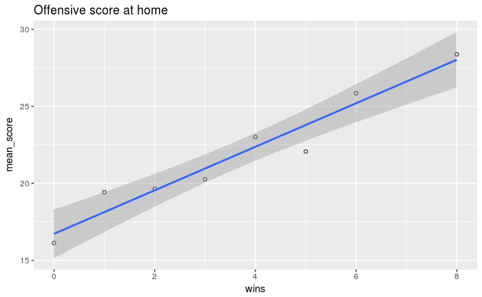

```r
# correlation analysis
# off.home, off.visit, def.home and def.visit are available here
require(ggplot2)
ggplot(off.home, aes(x=wins, y=mean_score)) + geom_point(shape=1) + geom_smooth(method='lm') + ggtitle('Offensive score at home')
```

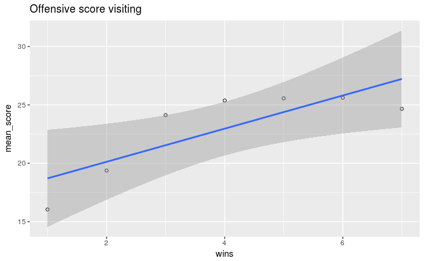

```r
ggplot(off.visit, aes(x=wins, y=mean_score)) + geom_point(shape=1) + geom_smooth(method='lm') + ggtitle('Offensive score visiting')
```

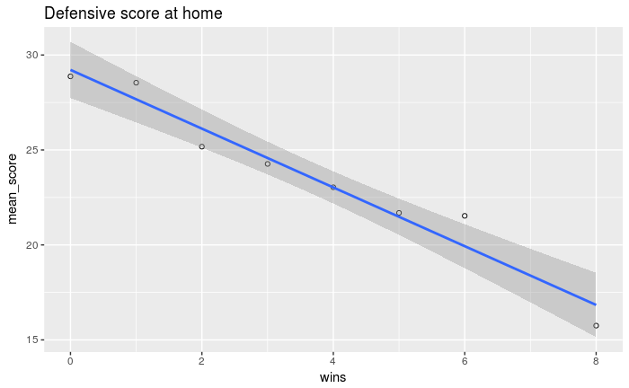

```r
ggplot(def.home, aes(x=wins, y=mean_score)) + geom_point(shape=1) + geom_smooth(method='lm') + ggtitle('Defensive score at home')
```

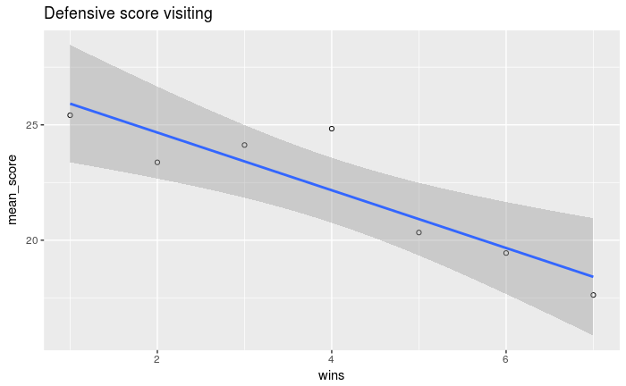

```r
ggplot(def.visit, aes(x=wins, y=mean_score)) + geom_point(shape=1) + geom_smooth(method='lm') + ggtitle('Defensive score visiting')
```

# 5 cleanup